# Tutorial 10: Natural experiments

Forschungspraktikum I und II: Längsschnittdatenanalyse in R

Dr. Christian Czymara

Early January 2015, the Jihadist terror attacks on staff of Charlie Hebdo and a Jewish supermarket shocked Europe. These attacks coincided with the fieldwork of the European Social Survey (ESS). We want to analyze whether the attacks had an effect on attitudes toward Muslim immigrants. We will draw upon a quasi-experimental design, comparing attitudes of those interviewed before with those interviewed after the attacks.

## 1. Preparation

### a) Packages

We will work with the following packages:

- `haven` (data import)
- `dplyr` (data manipulation)
- `magrittr` (piping)
- `lubridate` (working with dates)
- `sjPlot` (tables & plots)

Install and load them.

```r
packages <- c("haven", # data import
              "dplyr", # data manipulation
              "magrittr", # piping
              "lubridate", #working with dates
              "sjPlot" # tables and plots
              )

# install if necessary
install.packages(setdiff(packages, rownames(installed.packages())))

# load
lapply(packages, library, character.only = TRUE)
```

```
## [[1]]
## [1] "haven"     "stats"     "graphics"  "grDevices" "utils"     "datasets"
## [7] "methods"   "base"
##
## [[2]]
## [1] "dplyr"     "haven"     "stats"     "graphics"  "grDevices" "utils"
## [7] "datasets"  "methods"   "base"
##
## [[3]]
##  [1] "magrittr"  "dplyr"     "haven"     "stats"     "graphics"  "grDevices"
##  [7] "utils"     "datasets"  "methods"   "base"
##
## [[4]]
##  [1] "lubridate" "magrittr"  "dplyr"     "haven"     "stats"     "graphics"
##  [7] "grDevices" "utils"     "datasets"  "methods"   "base"
##
## [[5]]
##  [1] "sjPlot"    "lubridate" "magrittr"  "dplyr"     "haven"     "stats"
##  [7] "graphics"  "grDevices" "utils"     "datasets"  "methods"   "base"
```

### b) Import data

Import ESS7_edit.dta and assign it to object ESS.

```r
ESS <- read_dta("ESS7_edit.dta")
```

## 2. Generate treatment variable

The crucial variable of our analysis is based on the interview date.

### a) Interview start

There are three variables for the start of the interview: its day (`inwdds`), month (`inwmms`), and year (`inwyys`). Based on these three variables, use `lubridate`’s `mdy()` function to generate a variable that indicates the interview (start) date. Note that `lubridate` works with the US date format where the month comes first, followed by day and year (hence, mdy). When did the first interview start? When did the last start?

```r
ESS$start <- mdy(paste(ESS$inwmms, ESS$inwdds, ESS$inwyys, sep="-") ) # order must be month,day,year

range(ESS$start, na.rm = T)
```

```
## [1] "2014-08-21" "2015-12-02"
```

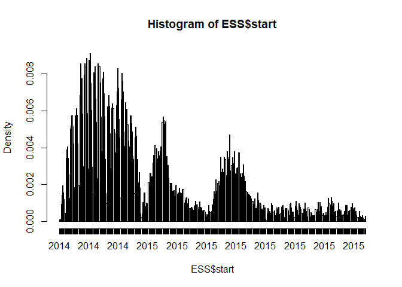

```r
# plot
hist(ESS$start, breaks = length(unique(ESS$start)))
```

### b) Same day interviews

Not all interviews were finished on the same day. We will remove those respondents. Similar to 2.a), generate a variable that indicates the end of an interview (based on variables `inwdde`, `inwmme`, and `inwyye`).

```r
ESS$end <- mdy(paste(ESS$inwmme, ESS$inwdde, ESS$inwyye, sep="-"))

range(ESS$end, na.rm = T)
```

```
## [1] "2014-08-21" "2015-12-02"
```

Then generate another variable with value 1 if interview start and finish were on the same day and 0 otherwise. How many respondents were interviewed over several days? Drop respondents that were not interviewed in one day.

```r
ESS$sameday <- ESS$start == ESS$end

table(ESS$sameday)
```

```
##
## FALSE  TRUE
##   268 39907
```

```r
# only keep repsondents interviewed on one day
ESS <- ESS[ESS$sameday == T, ]
```

### c) Attack variable

We are prepared to create our treatment variable based on the attacks. They took place from 7 January to 9 Jan 2015. Hence, we need to transform this date. We will compare individuals interviewed up to four weeks (28 days) before the attack with those interviewed up to two weeks (14 days) after.

#### Before attack

Generate a variable that includes the period starting from *28 days before 7 January 2015* to *the day before 7 January 2015*.

```r
ESS$attack_before <-
  ESS$start > as.Date("2015-1-7") - 28 &
    ESS$start < as.Date("2015-1-7")
```

#### After attack

Generate a variable that includes the period starting *the day after 7 January 2015* until *two weeks after 9 (!) January 2015*.

```r
ESS$attack_after <-
  ESS$start > as.Date("2015-1-7") &
  ESS$start <= as.Date("2015-1-7") + 2 + 14
```

#### Treatment variable

Generate our final binary treatment that should be 0 for those interviewed in the before period and 1 for those interviewed in the after period, NA otherwise. How many people were interviewed before the attack and how many after?

```r
ESS$attack <- ifelse(ESS$attack_before == T, 0,
                     ifelse(ESS$attack_after == T, 1,
                            NA
                            ))

table(ESS$attack, useNA = "ifany")
```

```
##
##     0     1  <NA>
##  2246  1984 35687
```

## 3. Analysis

### a) Descriptive overview

What was the average attitude toward Muslim immigration (`almuslv`, higher values imply a more negative attitude) before and after the attack?

```r
ESS %>%
  group_by(attack) %>%
  summarise_at("almuslv", mean, na.rm = TRUE)
```

```
## # A tibble: 3 × 2
##   attack almuslv
##    <dbl>   <dbl>
## 1      0    2.69
## 2      1    2.79
## 3     NA    2.70
```

### b) Linear regression

Run an OLS regression with the attack variable as predictor Is there an effect of the attack? Would you say it is causal?

```r
summary(lm(almuslv ~ attack, ESS))
```

```
##
## Call:
## lm(formula = almuslv ~ attack, data = ESS)
##
## Residuals:
##     Min      1Q  Median      3Q     Max
## -1.7946 -0.6910  0.2054  1.2054  1.3090
##
## Coefficients:
##             Estimate Std. Error t value Pr(>|t|)
## (Intercept)  2.69097    0.02102 128.009  < 2e-16 ***
## attack       0.10364    0.03069   3.377 0.000739 ***
## ---
## Signif. codes:  0 '***' 0.001 '**' 0.01 '*' 0.05 '.' 0.1 ' ' 1
##
## Residual standard error: 0.9817 on 4107 degrees of freedom
##   (35808 Beobachtungen als fehlend gelöscht)
## Multiple R-squared:  0.002769,   Adjusted R-squared:  0.002526
## F-statistic:  11.4 on 1 and 4107 DF,  p-value: 0.0007395
```

### c) Controls

Is the attack effect stable to adding `agea`, `hinctnta`, and `edulvlb` as control variables?

```r
summary(lm(almuslv ~ attack + agea + hinctnta + edulvlb, ESS))
```

```
##
## Call:
## lm(formula = almuslv ~ attack + agea + hinctnta + edulvlb, data = ESS)
##
## Residuals:
##     Min      1Q  Median      3Q     Max
## -2.1416 -0.7028  0.0719  0.8412  3.2007
##
## Coefficients:
##               Estimate Std. Error t value Pr(>|t|)
## (Intercept)  2.665e+00  6.769e-02  39.379  < 2e-16 ***
## attack       1.375e-01  3.315e-02   4.147 3.45e-05 ***
## agea         6.806e-03  9.719e-04   7.002 3.03e-12 ***
## hinctnta    -3.806e-02  6.260e-03  -6.080 1.34e-09 ***
## edulvlb     -4.053e-04  5.697e-05  -7.115 1.37e-12 ***
## ---
## Signif. codes:  0 '***' 0.001 '**' 0.01 '*' 0.05 '.' 0.1 ' ' 1
##
## Residual standard error: 0.9574 on 3342 degrees of freedom
##   (36570 Beobachtungen als fehlend gelöscht)
## Multiple R-squared:  0.05785,    Adjusted R-squared:  0.05673
## F-statistic:  51.3 on 4 and 3342 DF,  p-value: < 2.2e-16
```

### c) France only

Is there an effect for France only?

```r
summary(lm(almuslv ~ attack + agea + hinctnta + edulvlb, ESS, subset = cntry == "FR"))
```

```
##
## Call:
## lm(formula = almuslv ~ attack + agea + hinctnta + edulvlb, data = ESS,
##     subset = cntry == "FR")
##
## Residuals:
##     Min      1Q  Median      3Q     Max
## -1.8323 -0.4947 -0.1606  0.5238  2.2151
##
## Coefficients:
##               Estimate Std. Error t value Pr(>|t|)
## (Intercept)  2.6199532  0.1560296  16.791  < 2e-16 ***
## attack      -0.1562529  0.0821708  -1.902   0.0579 .
## agea         0.0056978  0.0022090   2.579   0.0102 *
## hinctnta    -0.0184511  0.0156148  -1.182   0.2380
## edulvlb     -0.0010980  0.0002273  -4.830 1.93e-06 ***
## ---
## Signif. codes:  0 '***' 0.001 '**' 0.01 '*' 0.05 '.' 0.1 ' ' 1
##
## Residual standard error: 0.8011 on 412 degrees of freedom
##   (1467 Beobachtungen als fehlend gelöscht)
## Multiple R-squared:  0.1251, Adjusted R-squared:  0.1166
## F-statistic: 14.73 on 4 and 412 DF,  p-value: 2.955e-11
```